# ARMA/ARIMA/SARIMA Models

Yifeng Chen

2023-04-26

```
## [1] "ADF test for Consumer Price Index"
```

```
##
##  Augmented Dickey-Fuller Test
##
## data:  log(data_cpi)
## Dickey-Fuller = -1.3859, Lag order = 9, p-value = 0.8383
## alternative hypothesis: stationary
```

```
## [1] "ADF test for Gross Domestic Product"
```

```
##
##  Augmented Dickey-Fuller Test
##
## data:  log(data_gdp)
## Dickey-Fuller = 0.23405, Lag order = 6, p-value = 0.99
## alternative hypothesis: stationary
```

```
## [1] "ADF test for Real Disposable Income"
```

```
##
##  Augmented Dickey-Fuller Test
##
## data:  log(data_rdi)
## Dickey-Fuller = -1.7387, Lag order = 9, p-value = 0.6889
## alternative hypothesis: stationary
```

```
##
##  Augmented Dickey-Fuller Test
##
## data:  diff1_data_cpi
## Dickey-Fuller = -5.5172, Lag order = 9, p-value = 0.01
## alternative hypothesis: stationary
```

```
##
##  Augmented Dickey-Fuller Test
##
## data:  diff1_data_gdp
## Dickey-Fuller = -5.6392, Lag order = 6, p-value = 0.01
## alternative hypothesis: stationary
```

```
##
##  Augmented Dickey-Fuller Test
##
## data:  diff1_data_rdi
## Dickey-Fuller = -11.07, Lag order = 9, p-value = 0.01
## alternative hypothesis: stationary
```

**By the first differencing now we can use all the variables to predict unemployment rate.**

**The main goal is to predict the unemployment rate, so for the actual AR/MA/ARMA/ARIMA goal for this section, we will use unemployment rate on that.**

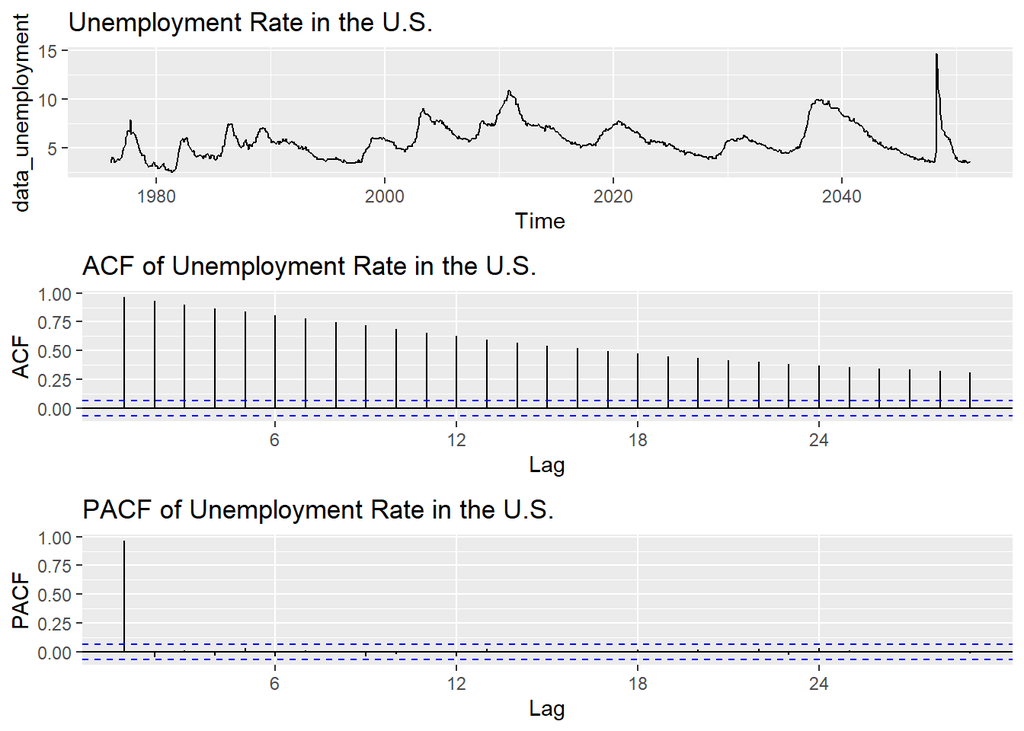

```
## [1] "ADF test for Unemployment Rate"
```

```
##
##  Augmented Dickey-Fuller Test
##
## data:  data_unemployment
## Dickey-Fuller = -3.8896, Lag order = 9, p-value = 0.01452
## alternative hypothesis: stationary
```

**From the unemployment rate plot and the ADF test we can see that we do not need to further difference the data** **The ARIMA would be (1, 0, 0) and suggest AR(1)**

```
##
## Call:
## arima(x = data_unemployment, order = c(1, 0, 0))
##
## Coefficients:
##          ar1  intercept
##       0.9707     5.5758
## s.e.  0.0080     0.4562
##
## sigma^2 estimated as 0.1724:  log likelihood = -489.12,  aic = 984.24
```

**Equation: Y_t = c + ϕ_1 Y_{t-1} + ε_t**

```
## Series: data_unemployment
## ARIMA(0,1,0)
##
## sigma^2 = 0.175:  log likelihood = -493.69
## AIC=989.38   AICc=989.38   BIC=994.18
```

**Since the ARIMA(1, 0, 0) has no AICc or BIC because only the PACF gives a value out of boundary at 1 and the data is already stationary without further differencing, we would use AIC to compare the 2 and the result is that the ARIMA(1, 0, 0) has a lower AIC than the auto-arima one, so we would go with the orignal one.**

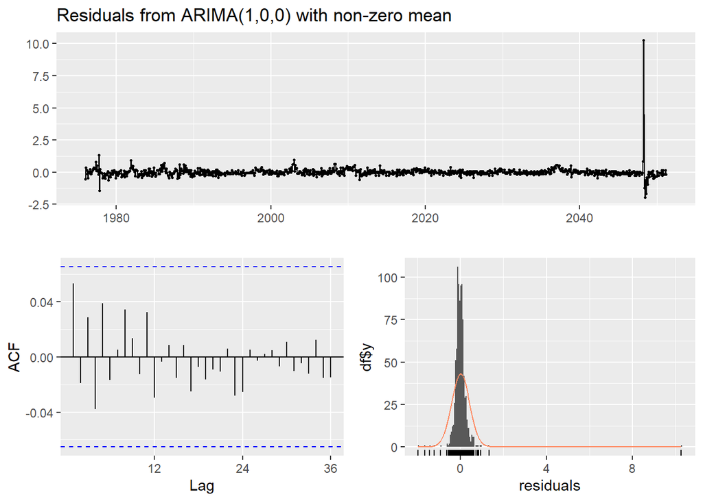

```
##
##  Ljung-Box test
##
## data:  Residuals from ARIMA(1,0,0) with non-zero mean
## Q* = 12.529, df = 23, p-value = 0.9615
##
## Model df: 1.   Total lags used: 24
```

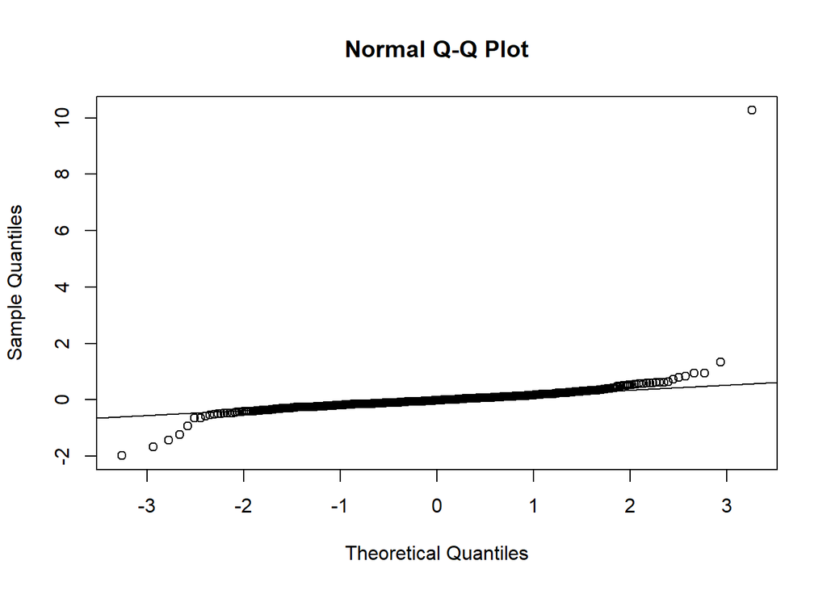

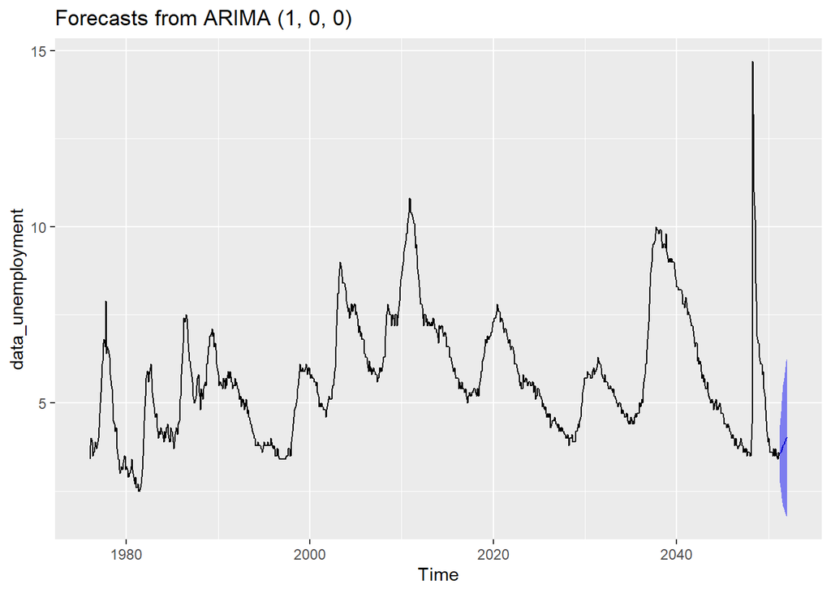

```r
# Split time series data into training and testing sets
train_data <- data_unemployment[1:720]
test_data <- data_unemployment[721:903]

# Fit ARIMA(1,0,0) model to training data
arima_model <- arima(train_data, order = c(1, 0, 0))

# Forecast future values with 95% confidence interval
forecast_result <- forecast(arima_model, h = length(test_data), level = 0.95)

# Calculate accuracy metrics for ARIMA model
accuracy_result_arima <- accuracy(forecast_result, test_data)

# Fit benchmark methods to training data
naive_model <- naive(train_data, h = length(test_data))

# Calculate accuracy metrics for benchmark methods
accuracy_result_naive <- accuracy(naive_model, test_data)

print("Accuracy metrics for ARIMA model:")
```

```
## [1] "Accuracy metrics for ARIMA model:"
```

```r
print(accuracy_result_arima)
```

```
##                       ME      RMSE       MAE         MPE      MAPE      MASE
## Training set 0.004842974 0.2127776 0.1503127 -0.05163726  2.800969  1.013835
## Test set     1.089968184 2.5479781 1.9758484  6.18219832 29.310265 13.326782
##                    ACF1
## Training set 0.09297823
## Test set             NA
```

```r
print("Accuracy metrics for Naive method:")
```

```
## [1] "Accuracy metrics for Naive method:"
```

```r
print(accuracy_result_naive)
```

```
##                       ME      RMSE       MAE         MPE      MAPE     MASE
## Training set 0.002225313 0.2133252 0.1482615 -0.02406309  2.754338  1.00000
## Test set     1.247540984 2.5832478 1.9633880  9.31856753 28.210152 13.24274
##                    ACF1
## Training set 0.09285828
## Test set             NA
```

```r
# Combine the actual data, training data, and test data forecasts
actual_data <- data_unemployment
arima_forecast <- c(train_data, as.vector(forecast_result$mean))
naive_forecast <- c(train_data, as.vector(naive_model$mean))

# Create a data frame
df <- data.frame(
  Date = c(time(actual_data), time(actual_data), time(actual_data)),
  Value = c(as.vector(actual_data), arima_forecast, naive_forecast),
  Type = rep(c("Actual", "ARIMA", "Naive"), each = length(actual_data))
)
```

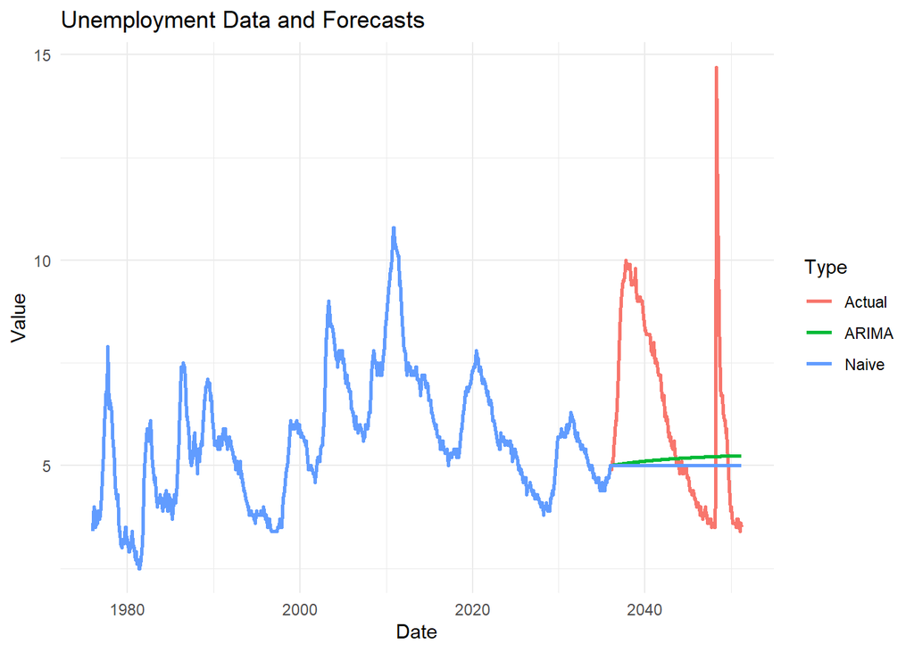

```r
# Plot the time series data and forecasts
p <- ggplot(df, aes(x = Date, y = Value, color = Type)) +
  geom_line(size = 1) +
  labs(title = "Unemployment Data and Forecasts",
       x = "Date",
       y = "Value",
       color = "Type") +
  theme_minimal()
# Display the plot
print(p)
```

**Overall, both models have their own strengths and weaknesses, if we only use test RMSE, we would go with ARIMA model**

**Unemployment rate is already seasonally adjusted, so we would not do SARIMA on that.**